# Regression models for paper - Breathing and speech adaptation

# Breathing data during LONE READ speech

## Participants

### Breathing rate

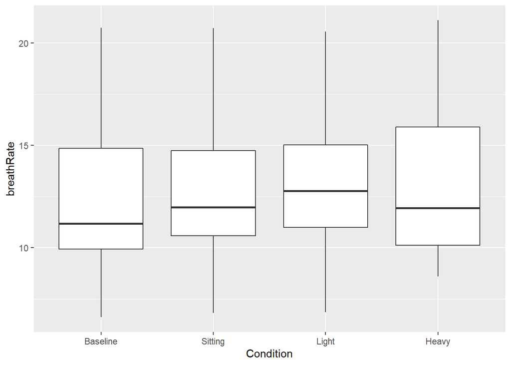

```r
ggplot(dat, aes(Condition, breathRate))+
  geom_boxplot()+
  scale_x_discrete(limits = orderCondBase)
```

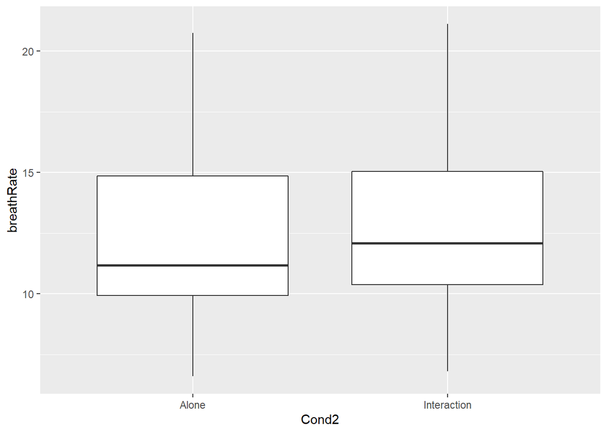

```r
ggplot(dat, aes(Cond2, breathRate))+
  geom_boxplot()
```

- Breathing rate doesn’t change across conditions (also not in baseline vs interaction).

```r
summary(b1 <- lmer(breathRate ~ Cond2 + (1 + Cond2 | Speaker), dat))
```

```
## Linear mixed model fit by REML ['lmerMod']
## Formula: breathRate ~ Cond2 + (1 + Cond2 | Speaker)
##    Data: dat
##
## REML criterion at convergence: 580.7
##
## Scaled residuals:
##     Min      1Q  Median      3Q     Max
## -4.0326 -0.4670 -0.0162  0.4983  2.8955
##
## Random effects:
##  Groups   Name             Variance Std.Dev. Corr
##  Speaker  (Intercept)      12.9421  3.5975
##           Cond2Interaction  0.7915  0.8897   -0.41
##  Residual                   2.6409  1.6251
## Number of obs: 132, groups:  Speaker, 22
##
## Fixed effects:
##                  Estimate Std. Error t value
## (Intercept)       12.4762     0.7926  15.740
## Cond2Interaction   0.5707     0.3406   1.676
##
## Correlation of Fixed Effects:
##             (Intr)
## Cnd2Intrctn -0.367
```

```r
summary(b1 <- lmer(breathRate ~ Condition + (1 | Speaker), dat))
```

```
## Linear mixed model fit by REML ['lmerMod']
## Formula: breathRate ~ Condition + (1 | Speaker)
##    Data: dat
##
## REML criterion at convergence: 581.3
##
## Scaled residuals:
##     Min      1Q  Median      3Q     Max
## -4.2762 -0.5070  0.0039  0.5393  2.3809
##
## Random effects:
##  Groups   Name        Variance Std.Dev.
##  Speaker  (Intercept) 11.797   3.435
##  Residual              2.909   1.706
## Number of obs: 132, groups:  Speaker, 22
##
## Fixed effects:
##                   Estimate Std. Error t value
## (Intercept)       13.19757    0.81759  16.142
## ConditionBaseline -0.72137    0.41991  -1.718
## ConditionLight    -0.35593    0.51428  -0.692
## ConditionHeavy    -0.09602    0.51428  -0.187
##
## Correlation of Fixed Effects:
##             (Intr) CndtnB CndtnL
## ConditnBsln -0.385
## ConditnLght -0.315  0.612
## ConditinHvy -0.315  0.612  0.500
```

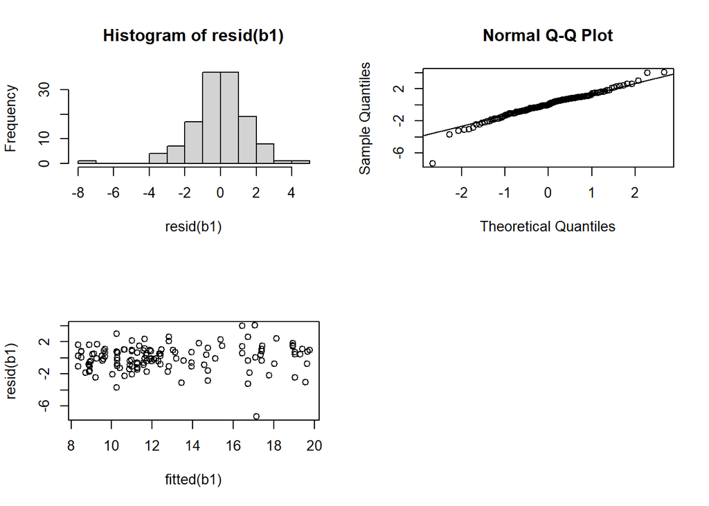

```r
par(mfrow=c(2, 2))
hist(resid(b1))
qqnorm(resid(b1));qqline(resid(b1))
plot(fitted(b1), resid(b1))
```

### Breath cycle duration

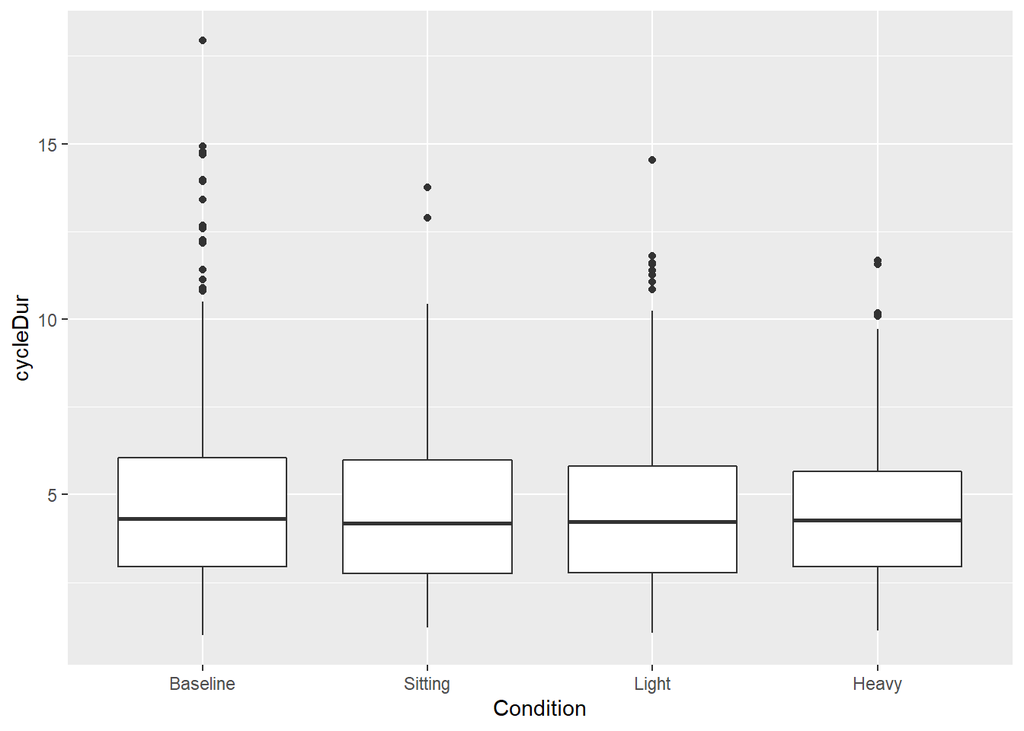

```r
ggplot(dat, aes(Condition, cycleDur))+
  geom_boxplot()+
  scale_x_discrete(limits = orderCondBase)
```

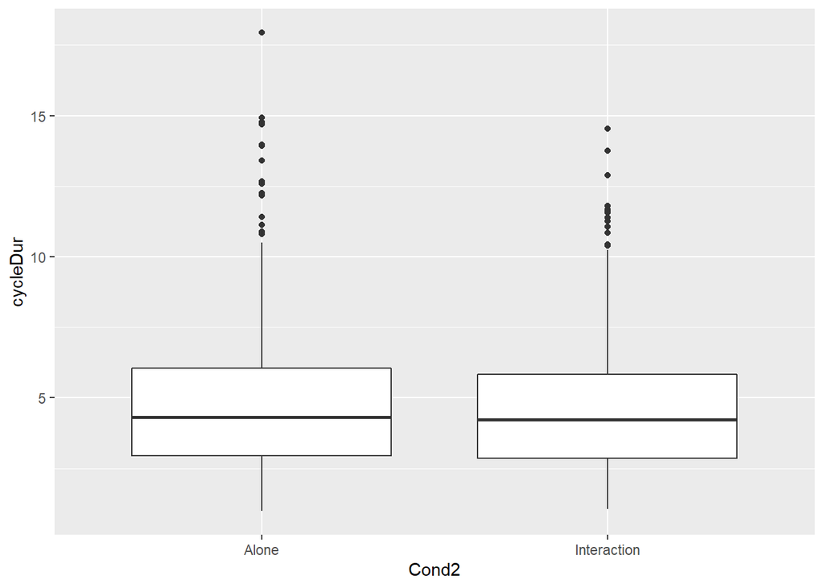

```r
ggplot(dat, aes(Cond2, cycleDur))+
  geom_boxplot()
```

There is **no** effect of condition on breath cycles.

```r
summary(b1 <- lmer(cycleDur ~ Condition + (1 | Speaker), dat))
```

```
## Linear mixed model fit by REML ['lmerMod']
## Formula: cycleDur ~ Condition + (1 | Speaker)
##    Data: dat
##
## REML criterion at convergence: 6864.3
##
## Scaled residuals:
##     Min      1Q  Median      3Q     Max
## -2.7295 -0.6708 -0.1101  0.5296  5.6557
##
## Random effects:
##  Groups   Name        Variance Std.Dev.
##  Speaker  (Intercept) 1.530    1.237
##  Residual             3.988    1.997
## Number of obs: 1608, groups:  Speaker, 22
##
## Fixed effects:
##                   Estimate Std. Error t value
## (Intercept)       4.867894   0.289839  16.795
## ConditionBaseline 0.248197   0.139976   1.773
## ConditionLight    0.125151   0.169548   0.738
## ConditionHeavy    0.009561   0.168804   0.057
##
## Correlation of Fixed Effects:
##             (Intr) CndtnB CndtnL
## ConditnBsln -0.352
## ConditnLght -0.291  0.605
## ConditinHvy -0.293  0.607  0.502
```

```r
summary(b1a <- lmer(cycleDur ~ Cond2 + (1 + Cond2 | Speaker), dat))
```

```
## Linear mixed model fit by REML ['lmerMod']
## Formula: cycleDur ~ Cond2 + (1 + Cond2 | Speaker)
##    Data: dat
##
## REML criterion at convergence: 6856.3
##
## Scaled residuals:
##     Min      1Q  Median      3Q     Max
## -2.7645 -0.6610 -0.0959  0.5289  5.5080
##
## Random effects:
##  Groups   Name             Variance Std.Dev. Corr
##  Speaker  (Intercept)      1.7221   1.3123
##           Cond2Interaction 0.1685   0.4104   -0.42
##  Residual                  3.9449   1.9862
## Number of obs: 1608, groups:  Speaker, 22
##
## Fixed effects:
##                  Estimate Std. Error t value
## (Intercept)        5.1526     0.2896  17.792
## Cond2Interaction  -0.2537     0.1340  -1.893
##
## Correlation of Fixed Effects:
##             (Intr)
## Cnd2Intrctn -0.408
```

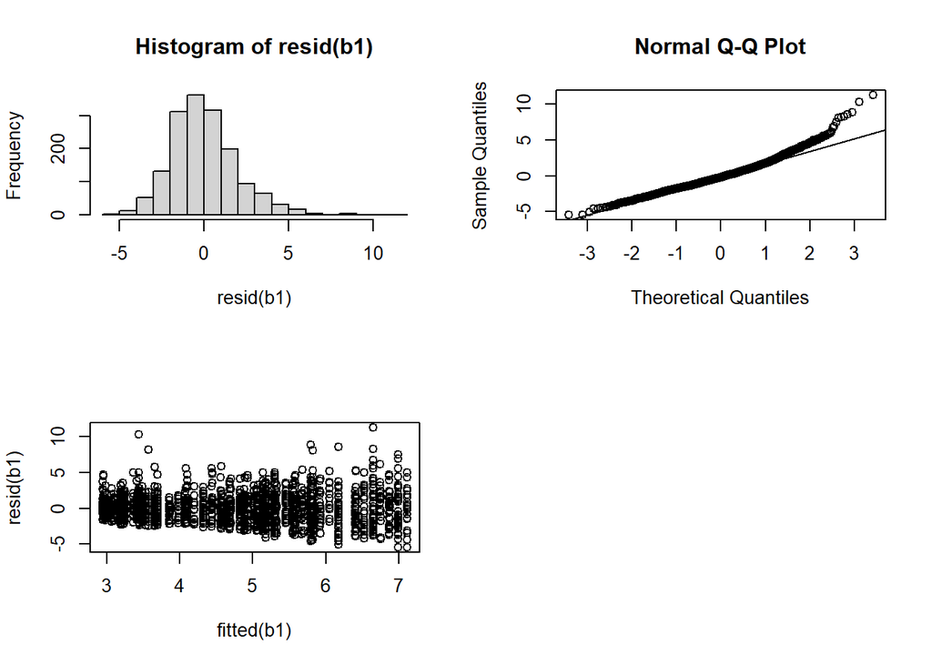

```r
par(mfrow=c(2, 2))
hist(resid(b1))
qqnorm(resid(b1));qqline(resid(b1))
plot(fitted(b1), resid(b1))

par(mfrow=c(2, 2))
```

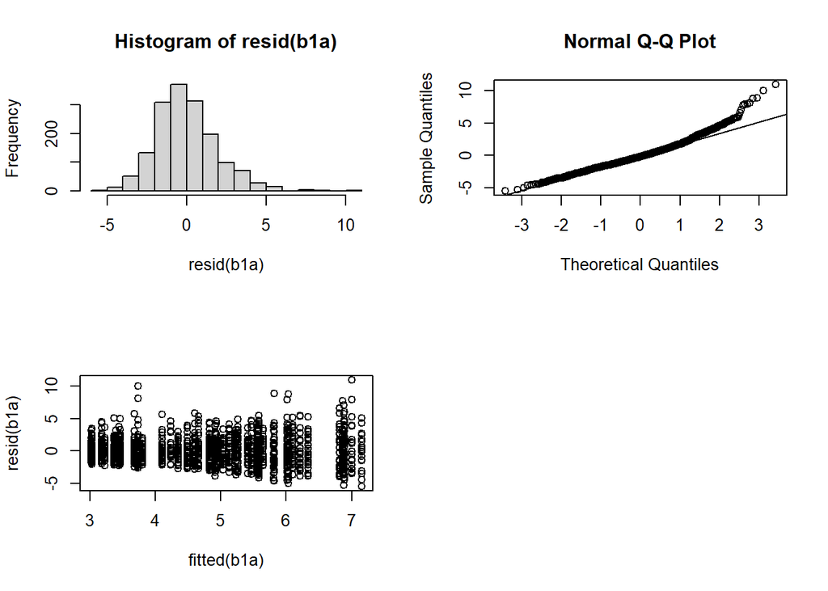

```r
hist(resid(b1a))
qqnorm(resid(b1a));qqline(resid(b1a))
plot(fitted(b1a), resid(b1a))
```

### Inhalation duration

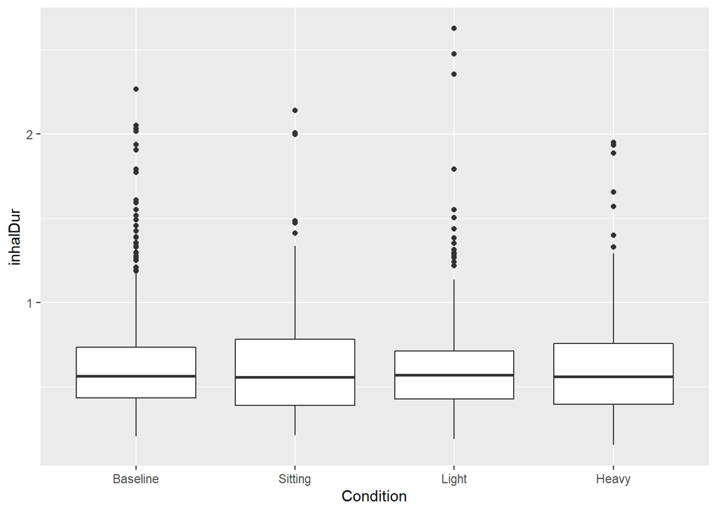

```r
ggplot(dat %>% filter(inhalDur < 3), aes(Condition, inhalDur))+
  geom_boxplot()+
  scale_x_discrete(limits = orderCondBase)
```

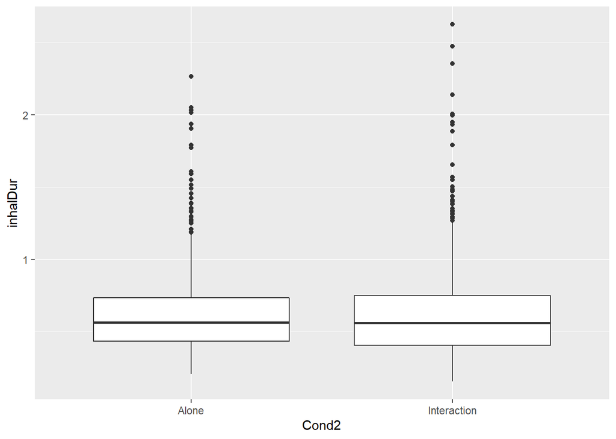

```r
ggplot(dat %>% filter(inhalDur < 3), aes(Cond2, inhalDur))+
  geom_boxplot()
```

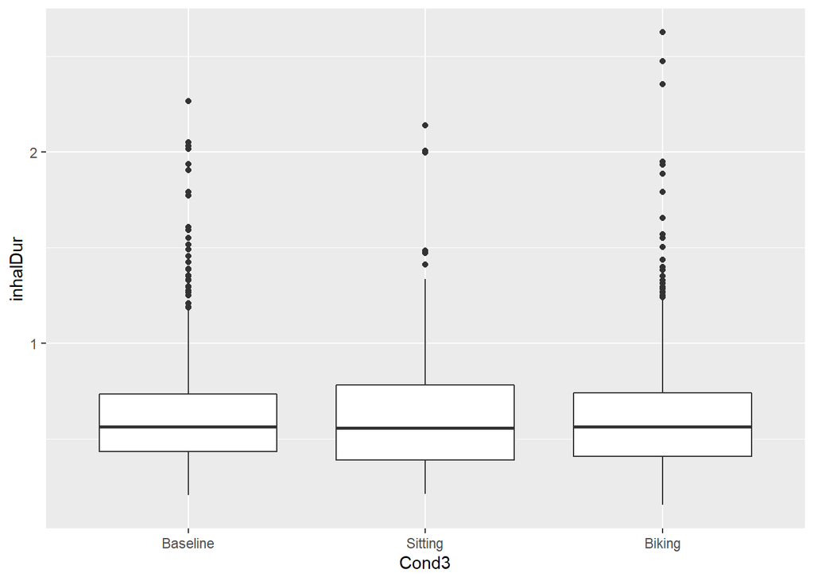

```r
ggplot(dat %>% filter(inhalDur < 3), aes(Cond3, inhalDur))+
  geom_boxplot()+
  scale_x_discrete(limits = c("Baseline", "Sitting", "Biking"))
```

Inhalation duration doesn’t change across conditions (nor Cond2 or Cond3).

```r
dat$Condition <- relevel(dat$Condition, ref="Sitting")
dat$Cond3 <- relevel(dat$Cond3, ref="Baseline")
summary(d5 <- lmer(inhalDur ~ Condition + (1 | Speaker), dat))
```

```
## Linear mixed model fit by REML ['lmerMod']
## Formula: inhalDur ~ Condition + (1 | Speaker)
##    Data: dat
##
## REML criterion at convergence: 610.3
##
## Scaled residuals:
##     Min      1Q  Median      3Q     Max
## -1.7398 -0.5934 -0.1780  0.3574 12.4738
##
## Random effects:
##  Groups   Name        Variance Std.Dev.
##  Speaker  (Intercept) 0.01520  0.1233
##  Residual             0.08154  0.2856
## Number of obs: 1608, groups:  Speaker, 22
##
## Fixed effects:
##                   Estimate Std. Error t value
## (Intercept)        0.66288    0.03140  21.108
## ConditionBaseline -0.01955    0.02001  -0.977
## ConditionLight    -0.01811    0.02424  -0.747
## ConditionHeavy    -0.03122    0.02413  -1.293
##
## Correlation of Fixed Effects:
##             (Intr) CndtnB CndtnL
## ConditnBsln -0.464
## ConditnLght -0.384  0.605
## ConditinHvy -0.386  0.607  0.501
```

```r
summary(d5a <- lmer(inhalDur ~ Cond2 + (1 + Cond2 | Speaker), dat))
```

```
## Linear mixed model fit by REML ['lmerMod']
## Formula: inhalDur ~ Cond2 + (1 + Cond2 | Speaker)
##    Data: dat
##
## REML criterion at convergence: 598.9
##
## Scaled residuals:
##     Min      1Q  Median      3Q     Max
## -1.7402 -0.5886 -0.1865  0.3596 12.4615
##
## Random effects:
##  Groups   Name             Variance Std.Dev. Corr
##  Speaker  (Intercept)      0.014790 0.12161
##           Cond2Interaction 0.001878 0.04334  -0.02
##  Residual                  0.081081 0.28475
## Number of obs: 1608, groups:  Speaker, 22
##
## Fixed effects:
##                  Estimate Std. Error t value
## (Intercept)       0.64224    0.02803  22.914
## Cond2Interaction  0.00582    0.01716   0.339
##
## Correlation of Fixed Effects:
##             (Intr)
## Cnd2Intrctn -0.240
```

```r
summary(d5b <- lmer(inhalDur ~ Cond3 + (1| Speaker), dat))
```

```
## Linear mixed model fit by REML ['lmerMod']
## Formula: inhalDur ~ Cond3 + (1 | Speaker)
##    Data: dat
##
## REML criterion at convergence: 605
##
## Scaled residuals:
##     Min      1Q  Median      3Q     Max
## -1.7399 -0.5936 -0.1770  0.3540 12.4769
##
## Random effects:
##  Groups   Name        Variance Std.Dev.
##  Speaker  (Intercept) 0.01521  0.1233
##  Residual             0.08150  0.2855
## Number of obs: 1608, groups:  Speaker, 22
##
## Fixed effects:
##               Estimate Std. Error t value
## (Intercept)   0.643310   0.028350  22.692
## Cond3Biking  -0.005167   0.015916  -0.325
## Cond3Sitting  0.019556   0.020007   0.977
##
## Correlation of Fixed Effects:
##             (Intr) Cnd3Bk
## Cond3Biking -0.239
## Cond3Sittng -0.192  0.337
```

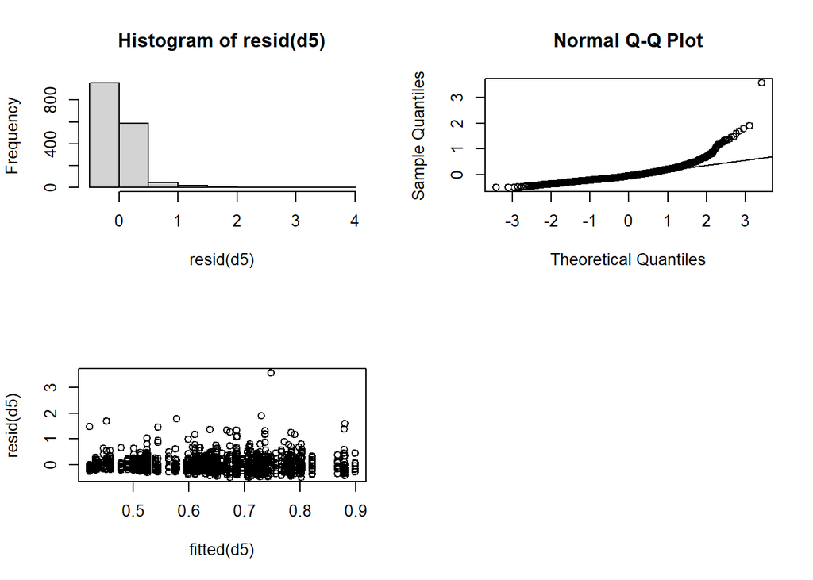

```r
par(mfrow=c(2, 2))
hist(resid(d5))
qqnorm(resid(d5));qqline(resid(d5))
plot(fitted(d5), resid(d5))
```

### Inhalation amplitude

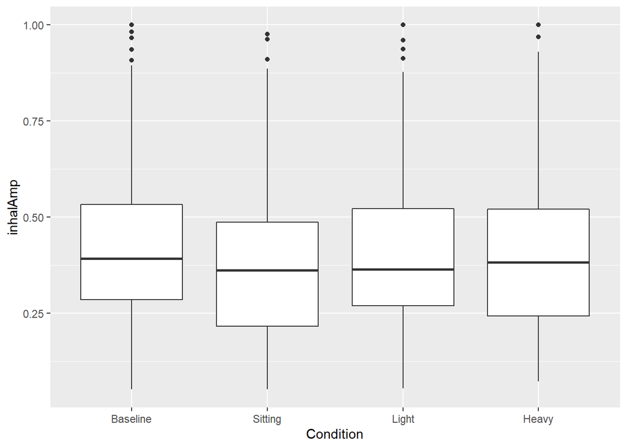

```r
ggplot(dat, aes(Condition, inhalAmp))+
  geom_boxplot()+
  scale_x_discrete(limits = orderCondBase)
```

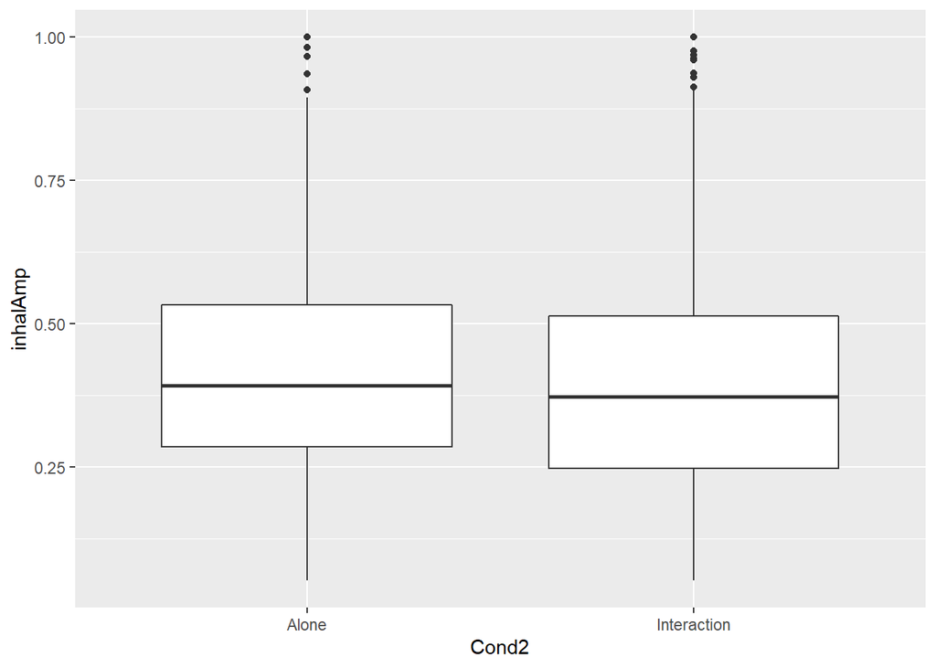

```r
ggplot(dat, aes(Cond2, inhalAmp))+
  geom_boxplot()
```

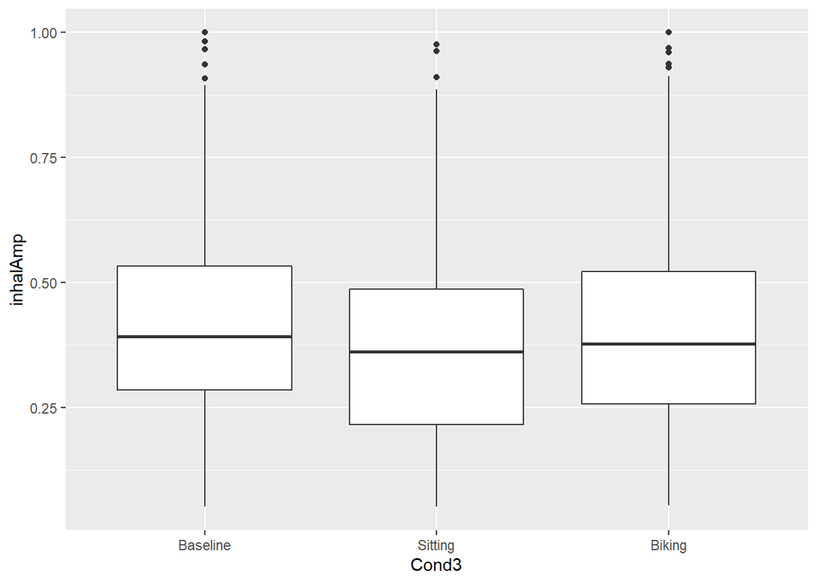

```r
ggplot(dat, aes(Cond3, inhalAmp))+
  geom_boxplot()+
  scale_x_discrete(limits = c("Baseline", "Sitting", "Biking"))
```

Inhalation amplitude did not change across conditions either (nor Cond2 or Cond3).

```r
dat$Condition <- relevel(dat$Condition, ref="Baseline")
dat$Cond3 <- relevel(dat$Cond3, ref="Sitting")

summary(a1 <- lmer(inhalAmp ~ Condition + (1 + Condition | Speaker), dat))
```

```
## Linear mixed model fit by REML ['lmerMod']
## Formula: inhalAmp ~ Condition + (1 + Condition | Speaker)
##    Data: dat
##
## REML criterion at convergence: -914.1
##
## Scaled residuals:
##     Min      1Q  Median      3Q     Max
## -2.5690 -0.6678 -0.1115  0.5634  4.4408
##
## Random effects:
##  Groups   Name             Variance Std.Dev. Corr
##  Speaker  (Intercept)      0.004087 0.06393
##           ConditionSitting 0.006214 0.07883  -0.09
##           ConditionLight   0.002321 0.04818   0.02  0.10
##           ConditionHeavy   0.004686 0.06845   0.11 -0.02  0.55
##  Residual                  0.030646 0.17506
## Number of obs: 1608, groups:  Speaker, 22
##
## Fixed effects:
##                  Estimate Std. Error t value
## (Intercept)       0.43450    0.01513  28.717
## ConditionSitting -0.03756    0.02100  -1.789
## ConditionLight   -0.01646    0.01621  -1.015
## ConditionHeavy   -0.01193    0.01922  -0.621
##
## Correlation of Fixed Effects:
##             (Intr) CndtnS CndtnL
## CondtnSttng -0.199
## ConditnLght -0.162  0.176
## ConditinHvy -0.071  0.090  0.405
```

```r
summary(a2 <- lmer(inhalAmp ~ Cond2 + (1 + Cond2 | Speaker), dat))
```

```
## Linear mixed model fit by REML ['lmerMod']
## Formula: inhalAmp ~ Cond2 + (1 + Cond2 | Speaker)
##    Data: dat
##
## REML criterion at convergence: -893.5
##
## Scaled residuals:
##     Min      1Q  Median      3Q     Max
## -2.5475 -0.6843 -0.1267  0.5689  3.6190
##
## Random effects:
##  Groups   Name             Variance Std.Dev. Corr
##  Speaker  (Intercept)      0.004040 0.06356
##           Cond2Interaction 0.002009 0.04482  0.03
##  Residual                  0.031967 0.17879
## Number of obs: 1608, groups:  Speaker, 22
##
## Fixed effects:
##                  Estimate Std. Error t value
## (Intercept)       0.43452    0.01512  28.737
## Cond2Interaction -0.02487    0.01324  -1.879
##
## Correlation of Fixed Effects:
##             (Intr)
## Cnd2Intrctn -0.202
```

```r
summary(a3 <- lmer(inhalAmp ~ Cond3 + (1 + Cond3 | Speaker), dat))
```

```
## Linear mixed model fit by REML ['lmerMod']
## Formula: inhalAmp ~ Cond3 + (1 + Cond3 | Speaker)
##    Data: dat
##
## REML criterion at convergence: -916.6
##
## Scaled residuals:
##     Min      1Q  Median      3Q     Max
## -2.5567 -0.6727 -0.1270  0.5746  4.4191
##
## Random effects:
##  Groups   Name          Variance Std.Dev. Corr
##  Speaker  (Intercept)   0.009355 0.09672
##           Cond3Baseline 0.006173 0.07857  -0.75
##           Cond3Biking   0.008538 0.09240  -0.58  0.83
##  Residual               0.030900 0.17578
## Number of obs: 1608, groups:  Speaker, 22
##
## Fixed effects:
##               Estimate Std. Error t value
## (Intercept)    0.39686    0.02329  17.042
## Cond3Baseline  0.03760    0.02098   1.792
## Cond3Biking    0.02297    0.02374   0.968
##
## Correlation of Fixed Effects:
##             (Intr) Cnd3Bs
## Cond3Baseln -0.771
## Cond3Biking -0.640  0.783
```

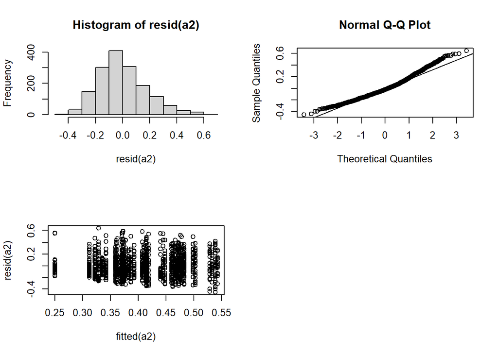

```r
par(mfrow=c(2, 2))
hist(resid(a2))
qqnorm(resid(a2));qqline(resid(a2))
plot(fitted(a2), resid(a2))
```

# Speech data: LONE READ speech

## Participants

### f0

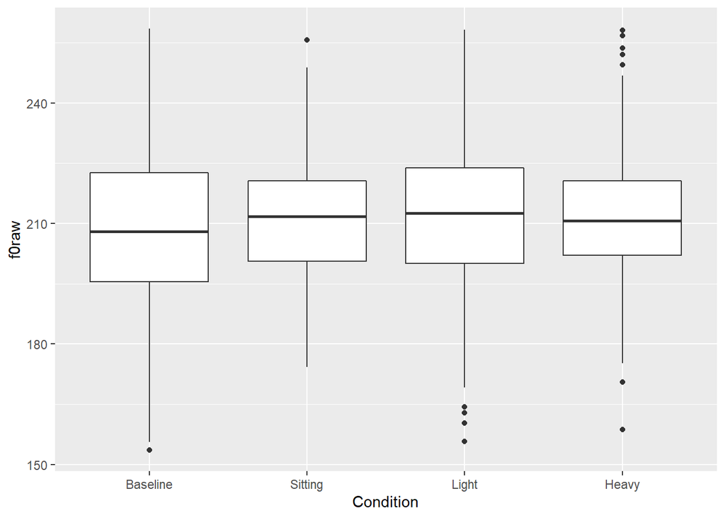

```r
ggplot(df, aes(Condition, f0raw))+
  geom_boxplot()
```

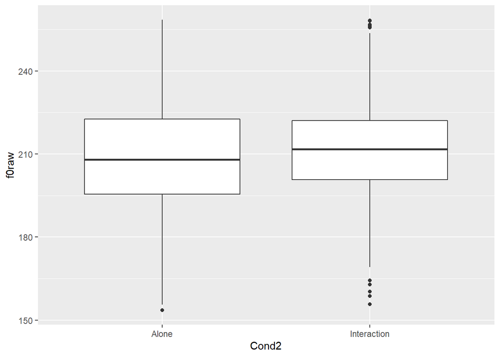

```r
ggplot(df, aes(Cond2, f0raw))+
  geom_boxplot()
```

The only f0 difference is between Baseline and Light (so I think this is noise?). Interaction vs. Alone is almost significant but not quite.

```r
df$Condition <- relevel(df$Condition, ref="Light")
summary(f1 <- lmer(f0raw ~ Condition + (1 + Condition | Speaker), df))
```

```
## boundary (singular) fit: see help('isSingular')
```

```
## Linear mixed model fit by REML ['lmerMod']
## Formula: f0raw ~ Condition + (1 + Condition | Speaker)
##    Data: df
##
## REML criterion at convergence: 23086.3
##
## Scaled residuals:
##     Min      1Q  Median      3Q     Max
## -4.5346 -0.6004 -0.0060  0.5821  3.7096
##
## Random effects:
##  Groups   Name              Variance Std.Dev. Corr
##  Speaker  (Intercept)       174.35   13.204
##           ConditionBaseline  74.87    8.653   -0.05
##           ConditionSitting   11.81    3.437   -0.94 -0.30
##           ConditionHeavy     33.89    5.821   -0.69  0.33  0.55
##  Residual                   163.48   12.786
## Number of obs: 2889, groups:  Speaker, 21
##
## Fixed effects:
##                   Estimate Std. Error t value
## (Intercept)        212.707      2.929  72.612
## ConditionBaseline   -4.796      2.006  -2.391
## ConditionSitting    -1.143      1.055  -1.084
## ConditionHeavy      -1.578      1.472  -1.072
##
## Correlation of Fixed Effects:
##             (Intr) CndtnB CndtnS
## ConditnBsln -0.097
## CondtnSttng -0.743 -0.072
## ConditinHvy -0.652  0.363  0.508
## optimizer (nloptwrap) convergence code: 0 (OK)
## boundary (singular) fit: see help('isSingular')
```

```r
summary(f1a <- lmer(f0raw ~ Cond2 + (1 + Cond2 | Speaker), df))
```

```
## Linear mixed model fit by REML ['lmerMod']
## Formula: f0raw ~ Cond2 + (1 + Cond2 | Speaker)
##    Data: df
##
## REML criterion at convergence: 23147.1
##
## Scaled residuals:
##     Min      1Q  Median      3Q     Max
## -4.4423 -0.6010 -0.0058  0.5943  3.6389
##
## Random effects:
##  Groups   Name             Variance Std.Dev. Corr
##  Speaker  (Intercept)      236.22   15.369
##           Cond2Interaction  75.31    8.678   -0.72
##  Residual                  168.20   12.969
## Number of obs: 2889, groups:  Speaker, 21
##
## Fixed effects:
##                  Estimate Std. Error t value
## (Intercept)       207.901      3.382  61.476
## Cond2Interaction    3.864      1.968   1.964
##
## Correlation of Fixed Effects:
##             (Intr)
## Cnd2Intrctn -0.717
```

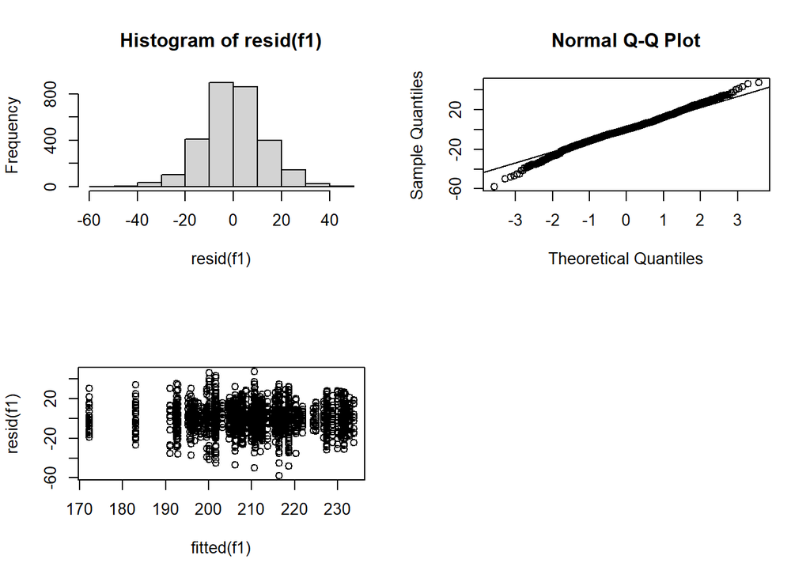

```r
par(mfrow=c(2, 2))
hist(resid(f1))
qqnorm(resid(f1));qqline(resid(f1))
plot(fitted(f1), resid(f1))
```

### Articulation rate

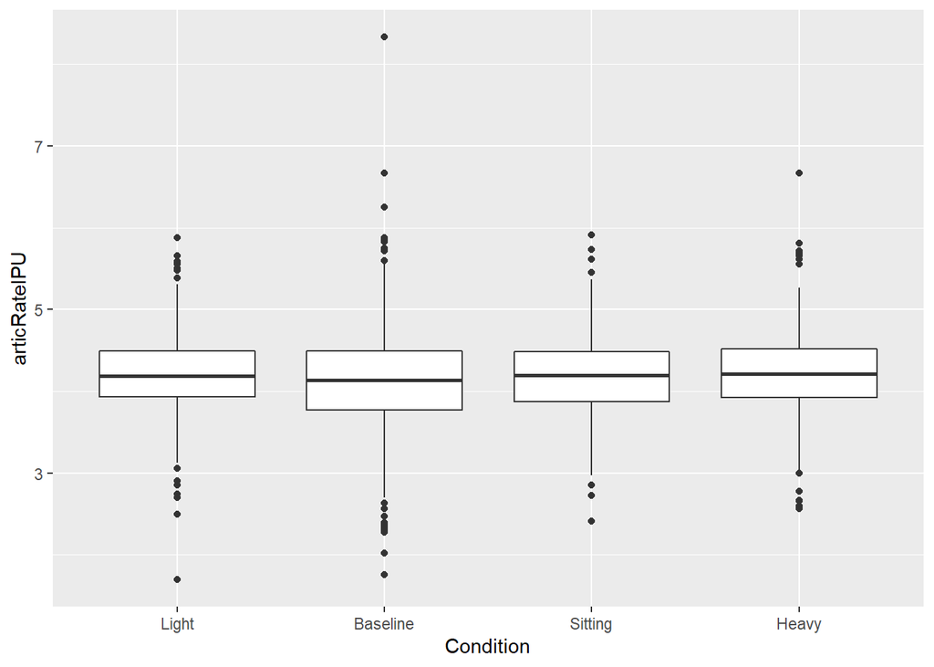

```r
ggplot(df, aes(Condition, articRateIPU))+
  geom_boxplot()
```

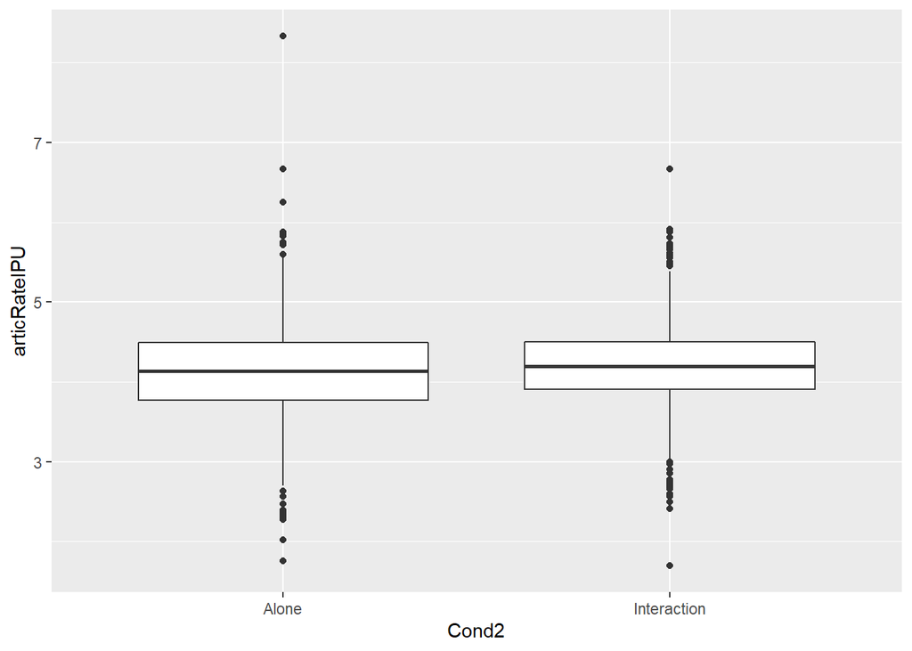

```r
ggplot(df, aes(Cond2, articRateIPU))+
  geom_boxplot()
```

Articulation rate didn’t change across conditions.

```r
df$Condition <- relevel(df$Condition, ref="Sitting")
summary(s1 <- lmer(articRateIPU ~ Condition + (1 | Speaker), df))
```

```
## Linear mixed model fit by REML ['lmerMod']
## Formula: articRateIPU ~ Condition + (1 | Speaker)
##    Data: df
##
## REML criterion at convergence: 4634.8
##
## Scaled residuals:
##     Min      1Q  Median      3Q     Max
## -4.6138 -0.5549 -0.0141  0.5865  7.9106
##
## Random effects:
##  Groups   Name        Variance Std.Dev.
##  Speaker  (Intercept) 0.02756  0.166
##  Residual             0.28405  0.533
## Number of obs: 2889, groups:  Speaker, 21
##
## Fixed effects:
##                   Estimate Std. Error t value
## (Intercept)        4.17857    0.04248  98.355
## ConditionLight     0.02708    0.03061   0.885
## ConditionBaseline -0.02064    0.02774  -0.744
## ConditionHeavy     0.05350    0.03065   1.745
##
## Correlation of Fixed Effects:
##             (Intr) CndtnL CndtnB
## ConditnLght -0.373
## ConditnBsln -0.412  0.577
## ConditinHvy -0.374  0.523  0.576
```

```r
summary(s2 <- lmer(articRateIPU ~ Cond2 + (1+Cond2 | Speaker), df))
```

```
## Linear mixed model fit by REML ['lmerMod']
## Formula: articRateIPU ~ Cond2 + (1 + Cond2 | Speaker)
##    Data: df
##
## REML criterion at convergence: 4625.3
##
## Scaled residuals:
##     Min      1Q  Median      3Q     Max
## -4.5970 -0.5506 -0.0191  0.5866  7.9134
##
## Random effects:
##  Groups   Name             Variance Std.Dev. Corr
##  Speaker  (Intercept)      0.03407  0.18459
##           Cond2Interaction 0.00276  0.05253  -0.62
##  Residual                  0.28355  0.53250
## Number of obs: 2889, groups:  Speaker, 21
##
## Fixed effects:
##                  Estimate Std. Error t value
## (Intercept)       4.16266    0.04381  95.017
## Cond2Interaction  0.04243    0.02393   1.773
##
## Correlation of Fixed Effects:
##             (Intr)
## Cnd2Intrctn -0.548
```

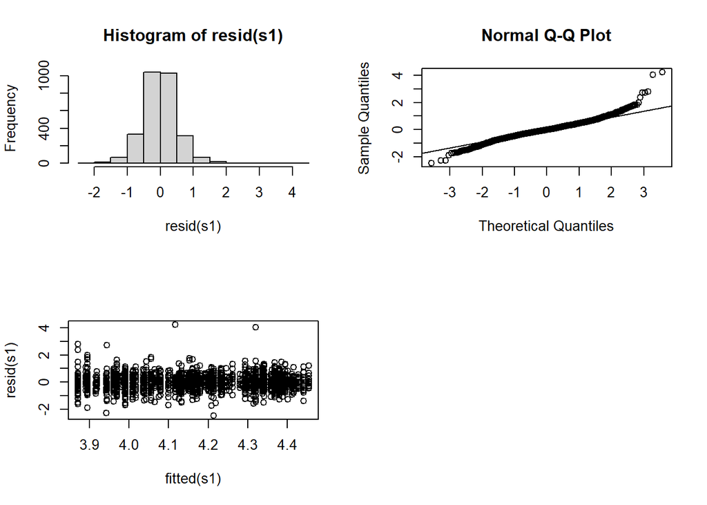

```r
par(mfrow=c(2, 2))
hist(resid(s1))
qqnorm(resid(s1));qqline(resid(s1))
plot(fitted(s1), resid(s1))

par(mfrow=c(2, 2))
```

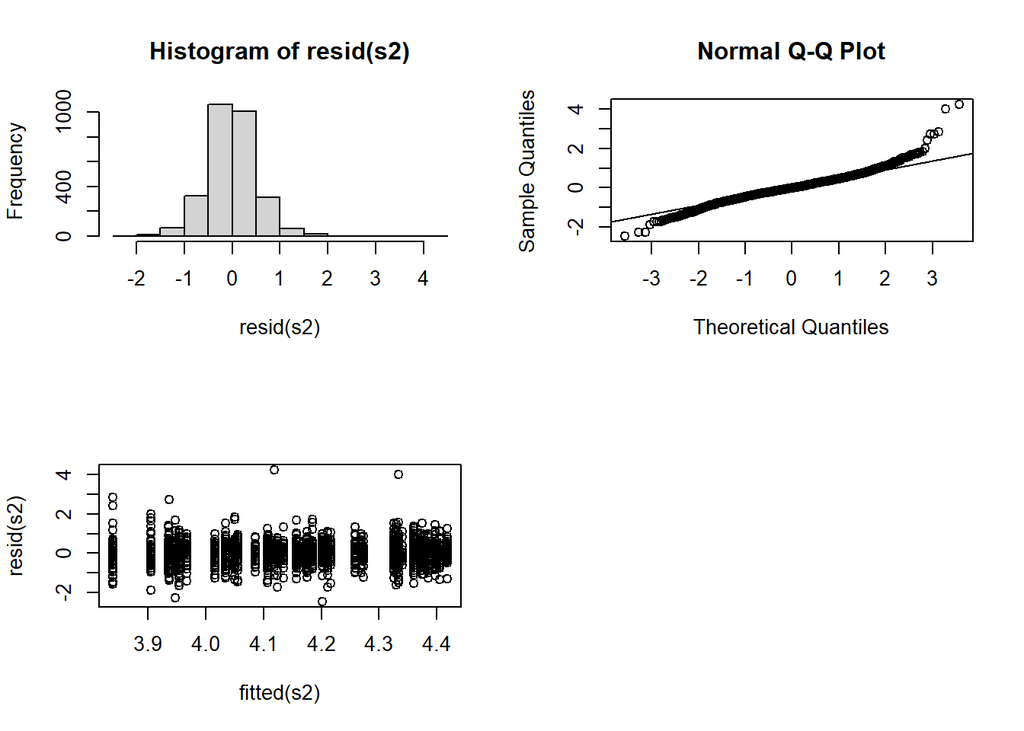

```r
hist(resid(s2))
qqnorm(resid(s2));qqline(resid(s2))
plot(fitted(s2), resid(s2))
```

# Breathing data: LONE vs SYNCHRONOUS READ SPEECH

## Participants

### Breathing rate

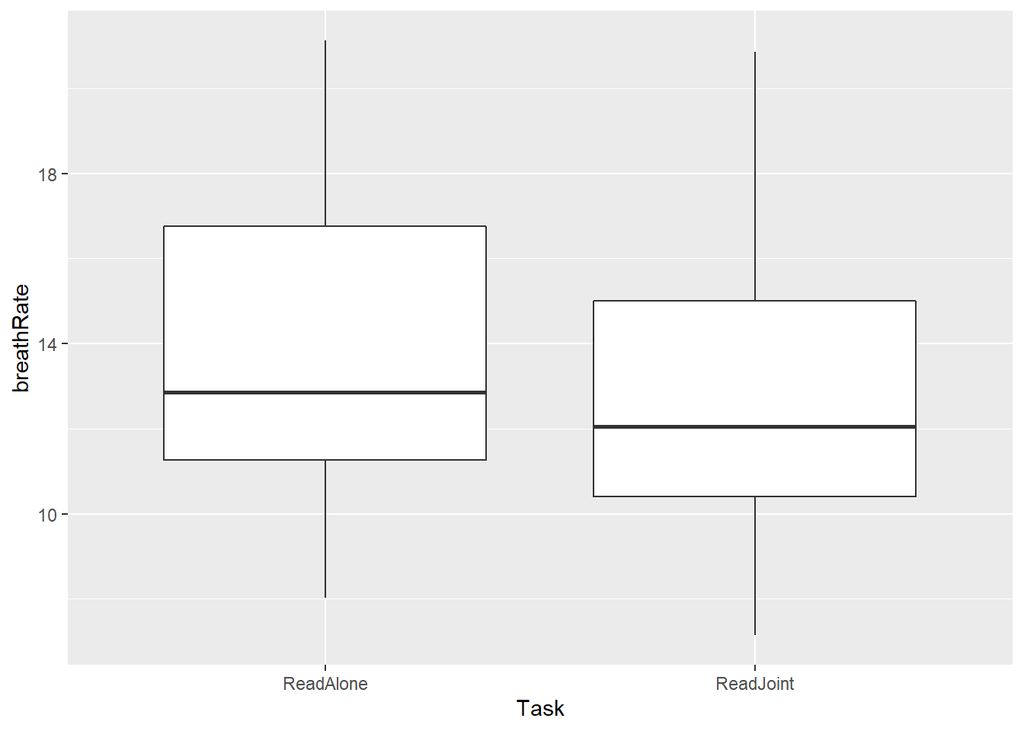

```r
ggplot(dat, aes(Task, breathRate))+
  geom_boxplot()
```

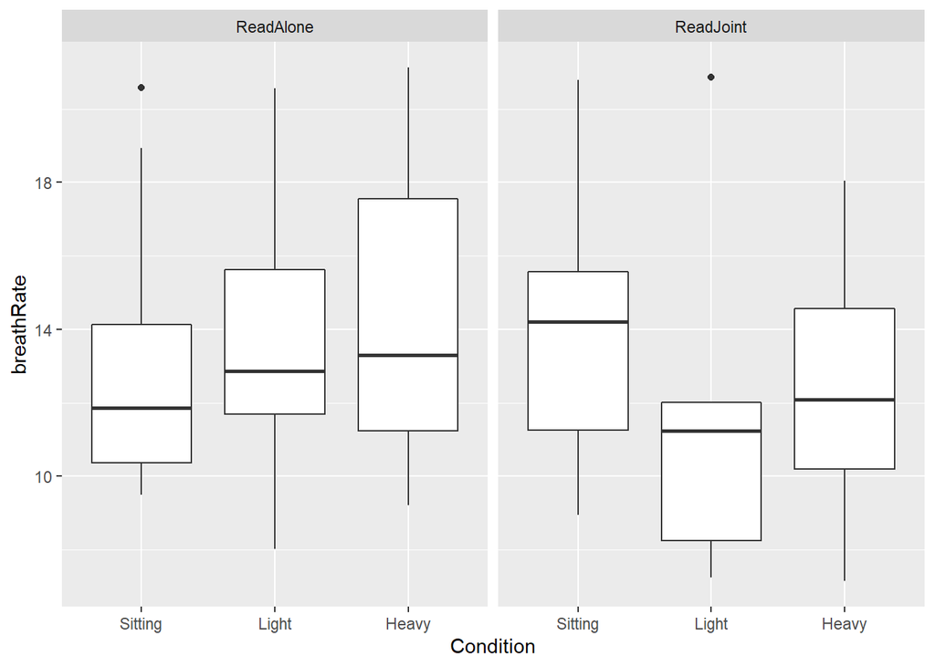

```r
ggplot(dat, aes(Condition, breathRate))+
  geom_boxplot()+
  facet_wrap(~Task)
```

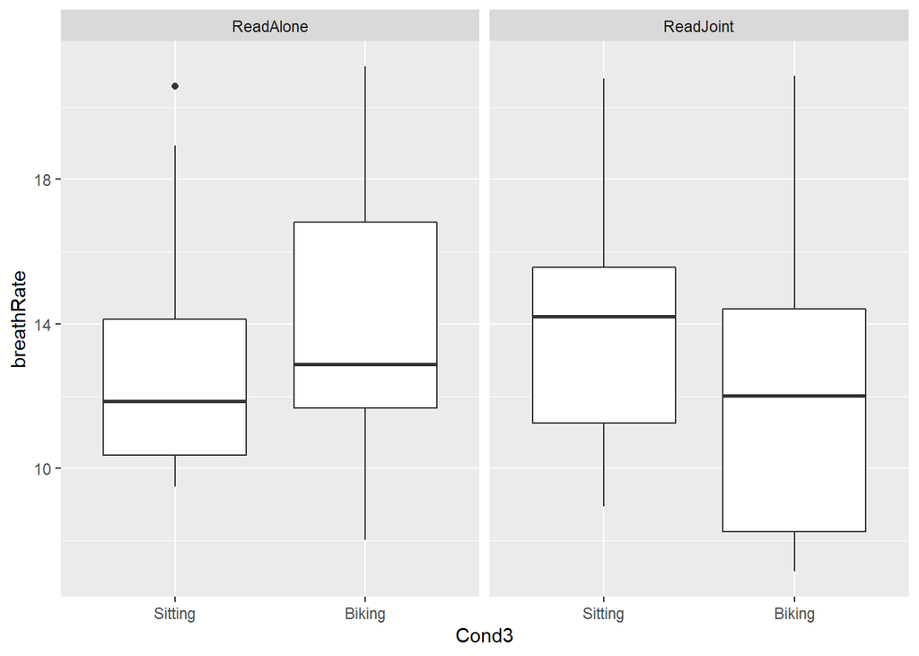

```r
ggplot(dat, aes(Cond3, breathRate))+
  geom_boxplot()+
  facet_wrap(~Task)+
  scale_x_discrete(limits = orderCond3)
```

- Breathing rate doesn’t change across Tasks (nor in interaction with condition).

```r
summary(b1 <- lmer(breathRate ~ Task + (1 | Speaker), dat))
```

```
## Linear mixed model fit by REML ['lmerMod']
## Formula: breathRate ~ Task + (1 | Speaker)
##    Data: dat
##
## REML criterion at convergence: 326.2
##
## Scaled residuals:
##      Min       1Q   Median       3Q      Max
## -2.53349 -0.49671 -0.07518  0.49214  2.92697
##
## Random effects:
##  Groups   Name        Variance Std.Dev.
##  Speaker  (Intercept) 10.875   3.298
##  Residual              4.251   2.062
## Number of obs: 66, groups:  Speaker, 22
##
## Fixed effects:
##               Estimate Std. Error t value
## (Intercept)    13.3637     0.7795  17.145
## TaskReadJoint   0.3054     0.6341   0.482
##
## Correlation of Fixed Effects:
##             (Intr)
## TaskReadJnt -0.283
```

```r
summary(b1a <- lmer(breathRate ~ Task:Cond3 + (1 | Speaker), dat))
```

```
## fixed-effect model matrix is rank deficient so dropping 1 column / coefficient
```

```
## Linear mixed model fit by REML ['lmerMod']
## Formula: breathRate ~ Task:Cond3 + (1 | Speaker)
##    Data: dat
##
## REML criterion at convergence: 322.8
##
## Scaled residuals:
##     Min      1Q  Median      3Q     Max
## -2.3854 -0.5266 -0.1075  0.5115  2.8230
##
## Random effects:
##  Groups   Name        Variance Std.Dev.
##  Speaker  (Intercept) 10.625   3.260
##  Residual              4.467   2.114
## Number of obs: 66, groups:  Speaker, 22
##
## Fixed effects:
##                            Estimate Std. Error t value
## (Intercept)                 13.8892     1.0156  13.676
## TaskReadAlone:Cond3Biking   -0.4438     0.8366  -0.531
## TaskReadJoint:Cond3Biking   -0.4285     1.0348  -0.414
## TaskReadAlone:Cond3Sitting  -0.6943     1.0775  -0.644
##
## Correlation of Fixed Effects:
##             (Intr) TRA:C3B TRJ:C3
## TskRdAl:C3B -0.636
## TskRdJn:C3B -0.541  0.580
## TskRdAl:C3S -0.579  0.685   0.601
## fit warnings:
## fixed-effect model matrix is rank deficient so dropping 1 column / coefficient
```

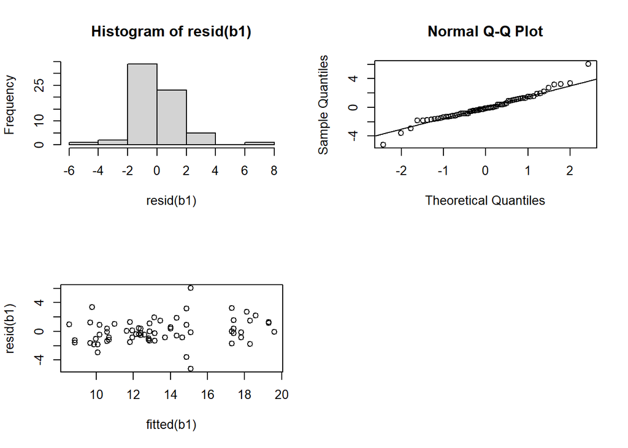

```r
par(mfrow=c(2, 2))
hist(resid(b1))
qqnorm(resid(b1));qqline(resid(b1))
plot(fitted(b1), resid(b1))
```

### Breath cycle duration

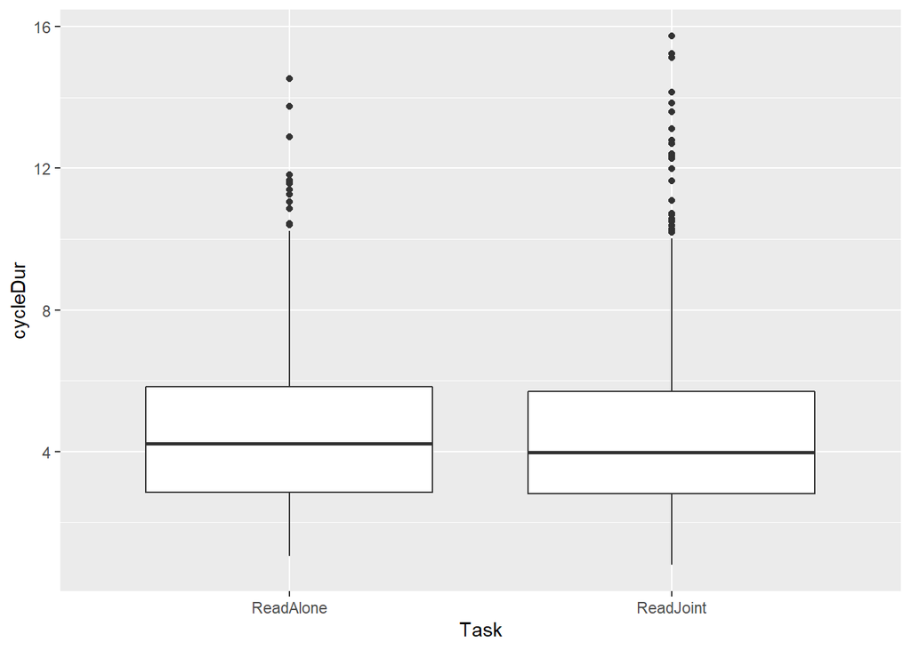

```r
ggplot(dat, aes(Task, cycleDur))+
  geom_boxplot()
```

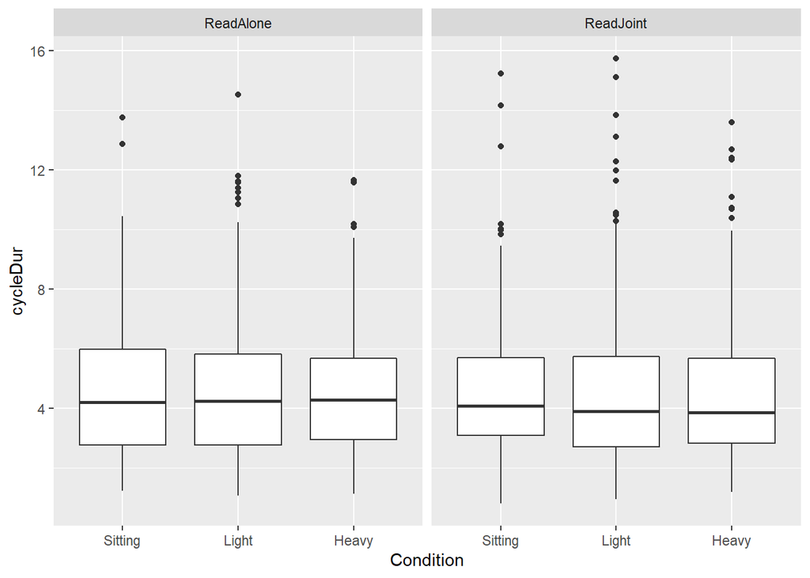

```r
ggplot(dat, aes(Condition, cycleDur))+
  geom_boxplot()+
  facet_wrap(~Task)
```

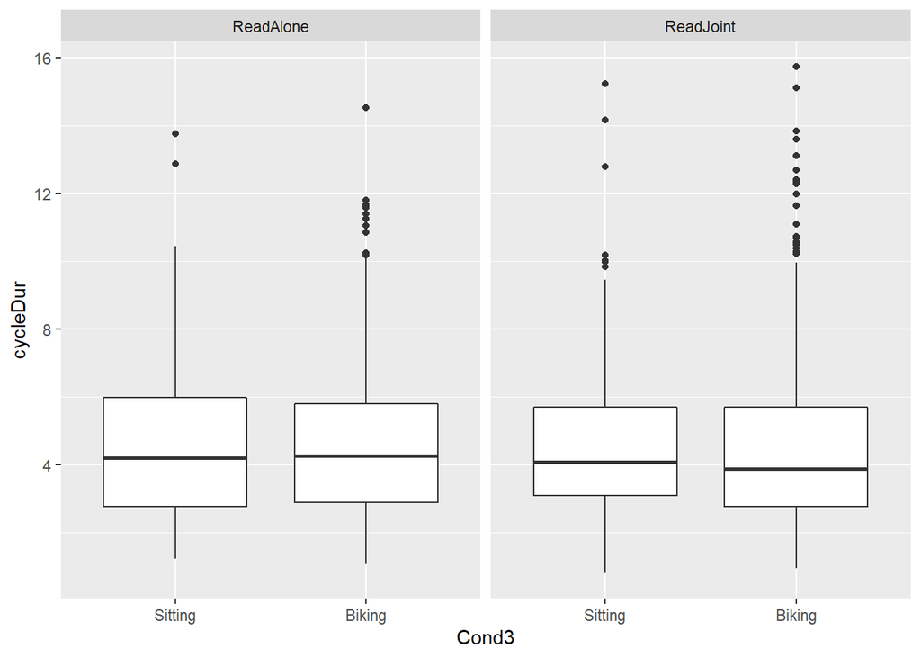

```r
ggplot(dat, aes(Cond3, cycleDur))+
  geom_boxplot()+
  facet_wrap(~Task)+
  scale_x_discrete(limits = orderCond3)
```

There is **no** effect of condition on breath cycles.

```r
summary(b1 <- lmer(cycleDur ~ Task + (1 +Task| Speaker), dat))
```

```
## Linear mixed model fit by REML ['lmerMod']
## Formula: cycleDur ~ Task + (1 + Task | Speaker)
##    Data: dat
##
## REML criterion at convergence: 7644.2
##
## Scaled residuals:
##     Min      1Q  Median      3Q     Max
## -2.6754 -0.6570 -0.1242  0.5327  5.0439
##
## Random effects:
##  Groups   Name          Variance Std.Dev. Corr
##  Speaker  (Intercept)   1.4766   1.2151
##           TaskReadJoint 0.5672   0.7531   -0.08
##  Residual               3.7050   1.9248
## Number of obs: 1817, groups:  Speaker, 22
##
## Fixed effects:
##               Estimate Std. Error t value
## (Intercept)    4.89520    0.26794  18.270
## TaskReadJoint -0.02507    0.18565  -0.135
##
## Correlation of Fixed Effects:
##             (Intr)
## TaskReadJnt -0.163
```

```r
summary(b1a <- lmer(cycleDur ~ Task:Condition + (1 +Task| Speaker), dat))
```

```
## fixed-effect model matrix is rank deficient so dropping 1 column / coefficient
```

```
## Linear mixed model fit by REML ['lmerMod']
## Formula: cycleDur ~ Task:Condition + (1 + Task | Speaker)
##    Data: dat
##
## REML criterion at convergence: 7650.7
##
## Scaled residuals:
##     Min      1Q  Median      3Q     Max
## -2.7090 -0.6674 -0.1220  0.5429  5.0648
##
## Random effects:
##  Groups   Name          Variance Std.Dev. Corr
##  Speaker  (Intercept)   1.4795   1.2164
##           TaskReadJoint 0.5678   0.7535   -0.08
##  Residual               3.7101   1.9262
## Number of obs: 1817, groups:  Speaker, 22
##
## Fixed effects:
##                                Estimate Std. Error t value
## (Intercept)                     4.80517    0.31049  15.476
## TaskReadAlone:ConditionSitting  0.04616    0.22298   0.207
## TaskReadJoint:ConditionSitting  0.07146    0.15290   0.467
## TaskReadAlone:ConditionLight    0.16710    0.22340   0.748
## TaskReadJoint:ConditionLight    0.13280    0.14711   0.903
## TaskReadAlone:ConditionHeavy    0.05885    0.22268   0.264
##
## Correlation of Fixed Effects:
##             (Intr) TRA:CS TRJ:CS TRA:CL TRJ:CL
## TskRdAln:CS -0.472
## TskRdJnt:CS -0.215  0.299
## TskRdAln:CL -0.471  0.731  0.298
## TskRdJnt:CL -0.222  0.309  0.451  0.309
## TskRdAln:CH -0.472  0.732  0.299  0.733  0.310
## fit warnings:
## fixed-effect model matrix is rank deficient so dropping 1 column / coefficient
```

```r
summary(b1b <- lmer(cycleDur ~ Task:Cond3 + (1 +Task| Speaker), dat))
```

```
## fixed-effect model matrix is rank deficient so dropping 1 column / coefficient
```

```
## Linear mixed model fit by REML ['lmerMod']
## Formula: cycleDur ~ Task:Cond3 + (1 + Task | Speaker)
##    Data: dat
##
## REML criterion at convergence: 7648.2
##
## Scaled residuals:
##     Min      1Q  Median      3Q     Max
## -2.6727 -0.6538 -0.1228  0.5352  5.0680
##
## Random effects:
##  Groups   Name          Variance Std.Dev. Corr
##  Speaker  (Intercept)   1.4780   1.2157
##           TaskReadJoint 0.5676   0.7534   -0.08
##  Residual               3.7086   1.9258
## Number of obs: 1817, groups:  Speaker, 22
##
## Fixed effects:
##                             Estimate Std. Error t value
## (Intercept)                 4.876587   0.315236  15.470
## TaskReadAlone:Cond3Biking   0.040871   0.214694   0.190
## TaskReadJoint:Cond3Biking  -0.009154   0.136419  -0.067
## TaskReadAlone:Cond3Sitting -0.025470   0.229542  -0.111
##
## Correlation of Fixed Effects:
##             (Intr) TRA:C3B TRJ:C3
## TskRdAl:C3B -0.527
## TskRdJn:C3B -0.306  0.450
## TskRdAl:C3S -0.493  0.799   0.421
## fit warnings:
## fixed-effect model matrix is rank deficient so dropping 1 column / coefficient
```

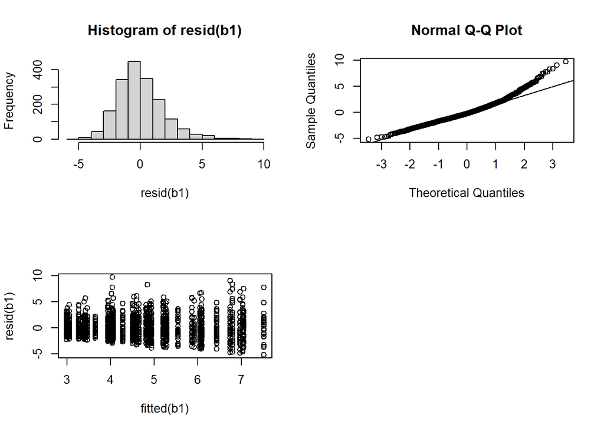

```r
par(mfrow=c(2, 2))
hist(resid(b1))
qqnorm(resid(b1));qqline(resid(b1))
plot(fitted(b1), resid(b1))

par(mfrow=c(2, 2))
```

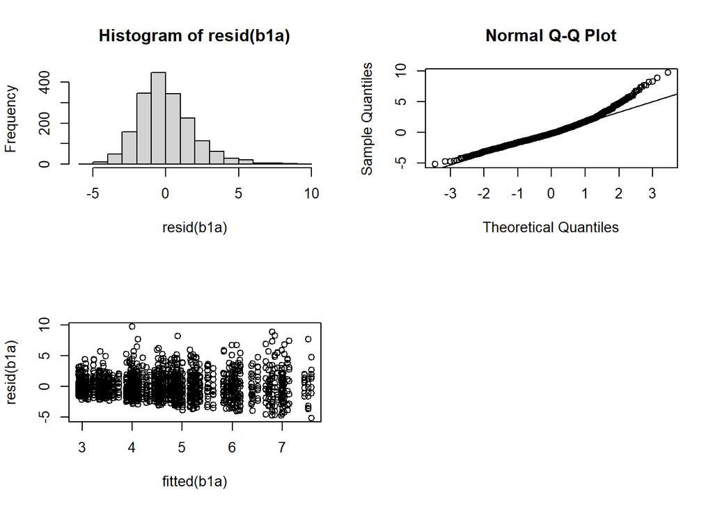

```r
hist(resid(b1a))
qqnorm(resid(b1a));qqline(resid(b1a))
plot(fitted(b1a), resid(b1a))
```

### Inhalation duration

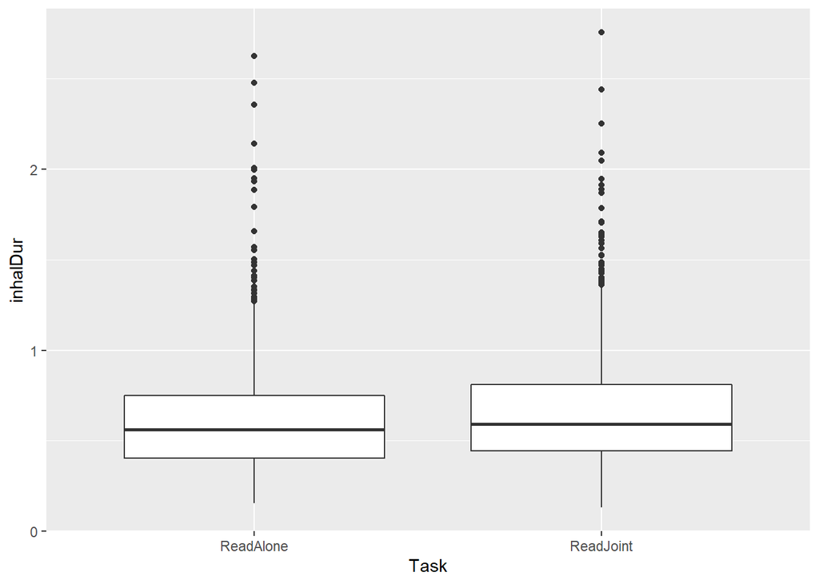

```r
ggplot(dat %>% filter(inhalDur < 3), aes(Task, inhalDur))+
  geom_boxplot()
```

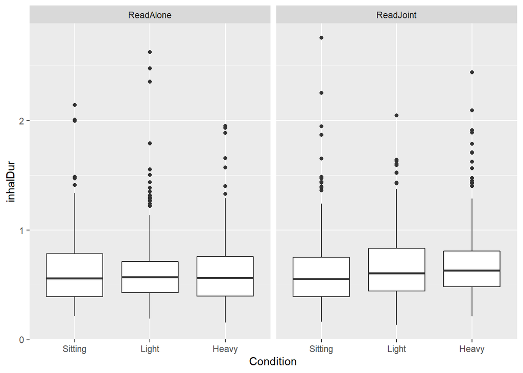

```r
ggplot(dat %>% filter(inhalDur < 3), aes(Condition, inhalDur))+
  geom_boxplot()+
  facet_wrap(~Task)
```

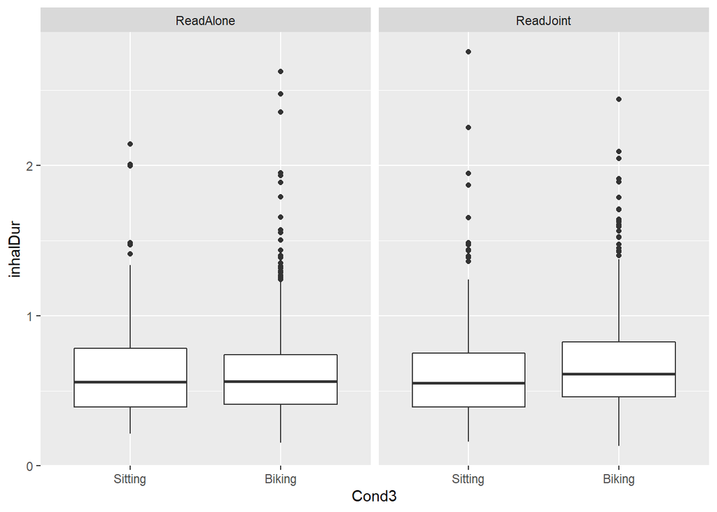

```r
ggplot(dat %>% filter(inhalDur < 3), aes(Cond3, inhalDur))+
  geom_boxplot()+
  facet_wrap(~Task)+
  scale_x_discrete(limits = orderCond3)
```

Inhalation duration doesn’t change across tasks.There are condition effects, which you can see in the separate sections above.

```r
dat$Condition <- relevel(dat$Condition, ref="Sitting")
dat$Cond3 <- relevel(dat$Cond3, ref="Sitting")
summary(d5 <- lmer(inhalDur ~ Task + (1+Task | Speaker), dat))
```

```
## Linear mixed model fit by REML ['lmerMod']
## Formula: inhalDur ~ Task + (1 + Task | Speaker)
##    Data: dat
##
## REML criterion at convergence: 1167.7
##
## Scaled residuals:
##     Min      1Q  Median      3Q     Max
## -1.7007 -0.5782 -0.2066  0.3364 12.9768
##
## Random effects:
##  Groups   Name          Variance Std.Dev. Corr
##  Speaker  (Intercept)   0.015696 0.1253
##           TaskReadJoint 0.007379 0.0859   -0.36
##  Residual               0.106444 0.3263
## Number of obs: 1817, groups:  Speaker, 22
##
## Fixed effects:
##               Estimate Std. Error t value
## (Intercept)    0.64835    0.02910  22.279
## TaskReadJoint  0.04477    0.02413   1.856
##
## Correlation of Fixed Effects:
##             (Intr)
## TaskReadJnt -0.436
```

```r
summary(d5a <- lmer(inhalDur ~ Task:Condition + (1+Task | Speaker), dat))
```

```
## fixed-effect model matrix is rank deficient so dropping 1 column / coefficient
```

```
## Linear mixed model fit by REML ['lmerMod']
## Formula: inhalDur ~ Task:Condition + (1 + Task | Speaker)
##    Data: dat
##
## REML criterion at convergence: 1178.9
##
## Scaled residuals:
##     Min      1Q  Median      3Q     Max
## -1.8096 -0.5791 -0.2069  0.3390 12.8926
##
## Random effects:
##  Groups   Name          Variance Std.Dev. Corr
##  Speaker  (Intercept)   0.01566  0.1251
##           TaskReadJoint 0.00743  0.0862   -0.35
##  Residual               0.10602  0.3256
## Number of obs: 1817, groups:  Speaker, 22
##
## Fixed effects:
##                                Estimate Std. Error t value
## (Intercept)                     0.72808    0.03167  22.989
## TaskReadAlone:ConditionSitting -0.06372    0.03191  -1.997
## TaskReadJoint:ConditionSitting -0.08041    0.02584  -3.112
## TaskReadAlone:ConditionLight   -0.08003    0.03198  -2.502
## TaskReadJoint:ConditionLight   -0.03453    0.02485  -1.389
## TaskReadAlone:ConditionHeavy   -0.09524    0.03184  -2.991
##
## Correlation of Fixed Effects:
##             (Intr) TRA:CS TRJ:CS TRA:CL TRJ:CL
## TskRdAln:CS -0.457
## TskRdJnt:CS -0.356  0.353
## TskRdAln:CL -0.455  0.625  0.351
## TskRdJnt:CL -0.368  0.365  0.451  0.365
## TskRdAln:CH -0.457  0.626  0.353  0.627  0.366
## fit warnings:
## fixed-effect model matrix is rank deficient so dropping 1 column / coefficient
```

```r
summary(d5b <- lmer(inhalDur ~ Task:Cond3 + (1+Task | Speaker), dat))
```

```
## fixed-effect model matrix is rank deficient so dropping 1 column / coefficient
```

```
## Linear mixed model fit by REML ['lmerMod']
## Formula: inhalDur ~ Task:Cond3 + (1 + Task | Speaker)
##    Data: dat
##
## REML criterion at convergence: 1170.3
##
## Scaled residuals:
##     Min      1Q  Median      3Q     Max
## -1.7571 -0.5780 -0.2093  0.3408 12.9438
##
## Random effects:
##  Groups   Name          Variance Std.Dev. Corr
##  Speaker  (Intercept)   0.015671 0.12518
##           TaskReadJoint 0.007434 0.08622  -0.35
##  Residual               0.106030 0.32562
## Number of obs: 1817, groups:  Speaker, 22
##
## Fixed effects:
##                            Estimate Std. Error t value
## (Intercept)                 0.71191    0.02951  24.120
## TaskReadAlone:Cond3Sitting -0.04758    0.02971  -1.602
## TaskReadJoint:Cond3Sitting -0.06420    0.02306  -2.785
## TaskReadAlone:Cond3Biking  -0.07155    0.02632  -2.718
##
## Correlation of Fixed Effects:
##             (Intr) TRA:C3S TRJ:C3
## TskRdAl:C3S -0.373
## TskRdJn:C3S -0.228  0.226
## TskRdAl:C3B -0.421  0.641   0.254
## fit warnings:
## fixed-effect model matrix is rank deficient so dropping 1 column / coefficient
```

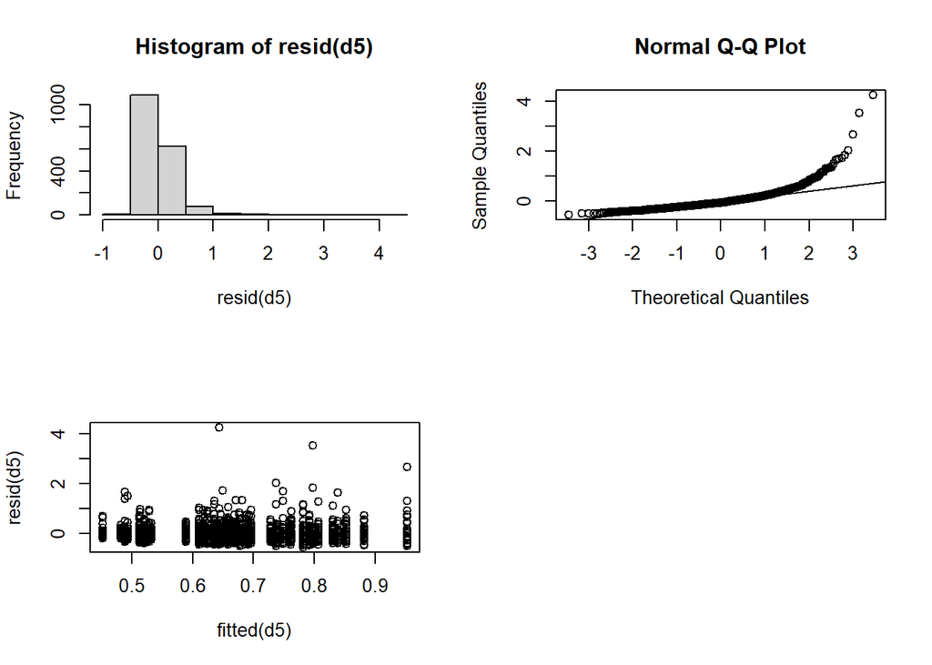

```r
par(mfrow=c(2, 2))
hist(resid(d5))
qqnorm(resid(d5));qqline(resid(d5))
plot(fitted(d5), resid(d5))
```